# Exploring data of Beer Supply and Demand

This page is meant for you, as a brewer, to guide your decision about which beers to brew, from style, to ABV, to IBU, and where the best places are to market and sell your brew.

Once you’re done exploring move on to the Predict tab so see how we think your beer will do in different markets.

# Beer consumption in the U.S.

This app shows where Untappd users are drinking different styles of beer, and is based on check-in data from [Untappd](https://untappd.com). Untappd users tend to be more heavily located on the U.S. coastal states, but you should still be able to still some unique differences amound beer style preferences among different regions of the country.

[interactive chart not shown]

### Users’ Preference by Brewery State

The choropleth map below highlights the states with the highest rated beers. While the total range in mean rating between states is pretty small, it is still fun to take pride in knowing your home state brews some *mean* beers.

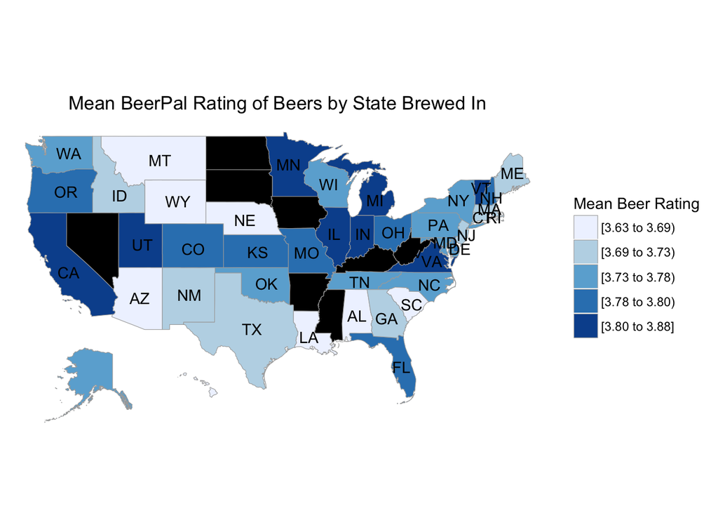

### Top Beers

The “rating” is average score of a Likert scale from 1 to 5, with 1 being “poor” and 5 being “great”. The “reviews” are how many times that beer was rated.

|  | state | Beer | Style | ABV | rating | reviews |
| --- | --- | --- | --- | --- | --- | --- |
| 1 | CA | AleSmith Speedway Stout | Imperial Stout | 12% | 4.411 | 92 |
| 2 | IL | Goose Island Bourbon County Stout | Imperial Stout | 14.50% | 4.323 | 73 |
| 3 | WI | New Glarus Belgian Red | Fruit Beer | 5.10% | 4.251 | 71 |
| 4 | IN | Three Floyds Dreadnaught Imperial IPA | Imperial IPA | 9.50% | 4.24 | 70 |
| 5 | DE | Dogfish Head World Wide Stout | Imperial Stout | 18% | 4.238 | 99 |
| 6 | CA | Stone Double Bastard Ale | American Barleywine | 11.20% | 4.236 | 83 |
| 7 | MI | Founders Kentucky Breakfast Bourbon Aged Stout | Imperial Stout | 10% | 4.227 | 35 |
| 8 | MI | Bells Hopslam | Imperial IPA | 10% | 4.22 | 58 |
| 9 | CA | Stone Imperial Russian Stout | Imperial Stout | 10.50% | 4.217 | 93 |
| 10 | CA | AleSmith YuleSmith - Summer | Imperial IPA | 9.50% | 4.21 | 46 |

[output cut: 936 more lines]